# EAI Tutorial 3.1

## Functions

Functions are a fundamental building block of R. To master many of the more advanced techniques such as functional programming, you need a solid foundation in how functions work. In this tutorial, you will first learn basic function types and function composition.

### Function Anatomy

All R functions have three parts which can be accessible with functions such as `body()`, `formals()`, `environment()`.

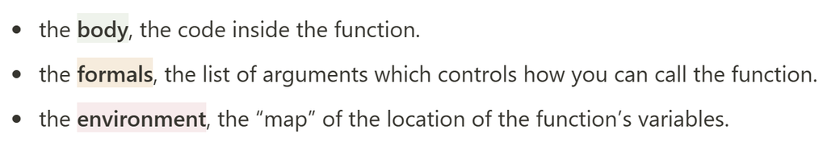

You can also add attributes (unsurprisingly with `attributes()`) to a function. For example, you can set the `class()` and add a custom `print()` method. To print all three parts of a function, just type function’s name without `()`.

### Making a Function Call

Unlike in many other languages, there is no special syntax for defining and naming a function: you simply create a function object (with `function`) and bind it to a name with `<-`:

```r
fun <- function(x) {
  sin(1 / x ^ 2)
}
```

You normally call a function by placing its arguments, wrapped in parentheses, after its name: `mean(1:10, na.rm = TRUE)`.

The last line of a function specifies return, so no extra syntax is needed. This is *implicit* return. However, you can specify function’s output (type) *explicitly* by using the `return()` function.Let’s play with syntax of basic functions in number of simpler tasks.

**Task 1:** When calling a function you can specify arguments by position, by complete name, or by partial name. Arguments are matched first by exact name (perfect matching), then by prefix matching, and finally by position. Examine the following code

```r
f <- function(abcdef, bcde1, bcde2) {
  list(a = abcdef, b1 = bcde1, b2 = bcde2)
}
```

and explain why these lines are good function calls:

```r
str(f(1, 2, 3))
str(f(2, 3, abcdef = 1))
str(f(2, 3, a = 1))
```

and this is a bad function call:

```r
str(f(1, 3, b = 1))
```

### Functional Delegation with `…`

Here is a special argument called `…` . This argument will match any arguments not otherwise matched that can be easily passed on to other functions. This is useful if you want to pass arguments to another function, but you don’t want to pre-specify their possible names. `…` is often used in conjunction with **S3** **generic functions** to allow individual methods to be more flexible.

**Task 2:** Write a function that takes a number of vectors and generates a data frame using `rbind()`. Set up the function in a way so that it accepts any number of variables and automatically returns the data frame.

Test your solution with these three vectors.

```r
a <- 1:10
b <- 2:11
c <- 3:12
```

### Primitive Functions

There is one exception to the rule that functions have three components. Primitive functions, like `sum()`, call C code directly with `.Primitive()` and contain no R code. Therefore their `formals()`, `body()`, and `environment()` are all `NULL`.

```r
sum
```

```
## function (..., na.rm = FALSE)  .Primitive("sum")
```

```r
formals(sum) # body(sum) ; environment(sum)
```

[output not shown]

Primitive functions are only found in the **base package**, and since they operate at a low level, they can be more efficient (primitive replacement functions don’t have to make copies), and can have different rules for argument matching (e.g., switch and call). This, however, comes at a cost of behaving differently from all other functions in R.

**Task 3:** Research online sources. Which function allows you to tell if an object is a function and which function tells you if an object is a primitive function?

### Generic Functions

A generic function is one which may be applied to different types of inputs producing results depending on the type of input. A typical example of generic function are functions such as `str()`, `print()` and `summary()`.

Summarizing object data is a common task. It appears, however, that the method by which that task is performed depends on the type of object that is input to the `summary()` function:

- If your object is a data frame, `summary()` behaves one way.
- If your object is a linear regression model, `summary()` does something else.

Since the behavior of `summary()` depends on the type of object involved in the operation of printing, you could say that it exhibits polymorphism. In fact it is the class of the object given to `summary()` that determines the method that `summary()` employs. To get full list of possible objects that can be printed out, type `methods(summary)`.

### Anonymous Functions

Most functions in R are **named functions** where a variable (or name) is assigned to the function. The name or variable is used to invoke the function. Functions without a variable name are known as **anonymous functions**. These functions, which are also referred to as $\lambda$ **pure functions**, are created temporarily and are utilized without having a variable name assigned to them.

A good rule of thumb is that an anonymous function should fit on one line and shouldn’t need to use `{}`. The most common use of anonymous functions is in combination with higher order functions — aka **functionals**, which you will learn shortly. However, lambdas can be invoked also individually as shown below:

```r
This is a named function: f <- function(x) { x + x} ; f(3)
This is an anonymous function: (function(x) x + x)(3)
```

Introduced in R 4.1, lambda syntax has been extended with a new shortcut `\`. Watch this out, as you might run into it on some of the fresh posts on the web:

```r
(\(x) x + x)(3)
```

There exists also another possibility implemented by the **tidyverse::purrr** **package** called `~` (pronounced tilde). The tilde `~` is commonly used when functionals such as `map()` are combined with lambdas.